# Assignment 2: Classification

Joram Keijser

Wednesday, December 10, 2014

### 0. Introduction

We begin by downloading and preprocessing the data.

```r
attributes <- c("party", "handicap", "water", "adoption", "physician", "el-salvador",
                "religious", "sattelite", "nicaraguan",
                "missile", "immigration", "synfuels", "education", "superfund", "crime",
                "dut-free", "export")
Data <- read.table("http://archive.ics.uci.edu/ml/machine-learning-databases/voting-records/house-votes-84.data", sep = ',', col.names = attributes, na.strings = "?")
```

There are 392 missing values. We replace the missing values by the most occuring value in the particular column. This is done by the `na.roughfix` function. The replacement is performed seperately for the two parties. For example, if most democrats voted yes on the topic of `handicap`, a missing democrat vote will taken to be yes as well.

```r
#Data <- na.roughfix(Data)
Data[Data[,1] == "democrat", ] <- na.roughfix(Data[Data[,1] == "democrat", ])
Data[Data[,1] == "republican", ] <- na.roughfix(Data[Data[,1] == "republican", ])
```

Next, we will take a first look at the data. There are 168 republicans and 267 democrats. On average, both parties voted in favour approximately half of the time. The biggest differences in voting behaviour are observed on the topic Physician. Only 5.2 percent of the democrats voted in favour. On the other hand, 98.8 of the republicans were in favour. This indicates that it should be possible to make accurate predictions, based only on the voting behaviour on this single topic.

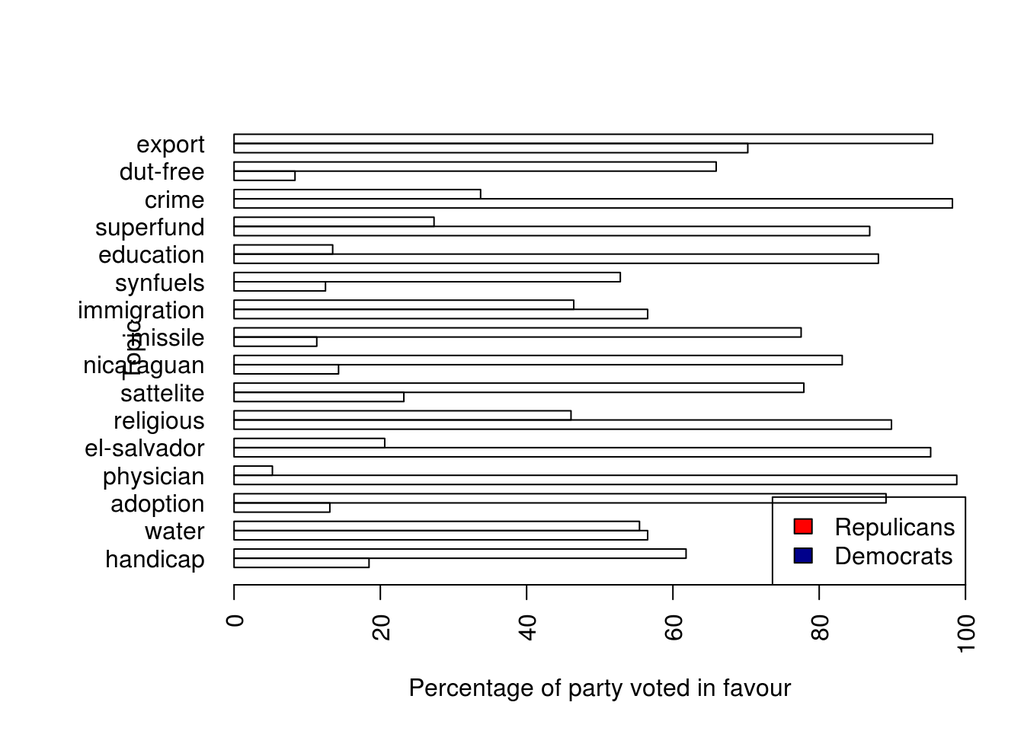

```r
## plot mean number of yes's per party
par(las=2)
par(mar=c(5,8,4,2))
colors = c("red", "darkblue")
barplot(100*as.matrix(meanVotes[,-1]), beside = TRUE, col = colours, horiz=T,
        xlim=c(0,100), xlab="Percentage of party voted in favour", ylab="Topic")
legend("bottomright", legend = c("Repulicans", "Democrats"), fill = colors)
```

```r
sort(apply(meanVotes[,-1], 2, function(x){
max(as.vector(x, mode = "numeric"))/min(as.vector(x, mode = "numeric"))}),
decreasing = TRUE)
```

```
##   physician    dut-free     missile    adoption   education  nicaraguan
##   18.844388    7.910112    6.855115    6.806946    6.533730    5.820225
## el-salvador    synfuels   sattelite    handicap   superfund       crime
##    4.623377    4.224719    3.355805    3.349040    3.178571    2.913690
##   religious      export immigration       water
##    1.951074    1.359741    1.217598    1.020150
```

Before we begin with the actual analysis, we divide the data in a training and test set.

```r
set.seed(14122014)
trainIndex <- sample.int(dim(Data)[1], size = round(dim(Data)[1]/2))
Train <- Data[trainIndex, ]
Test <- Data[-trainIndex, ]
```

### 1. Naive Bayes classification

Train Naive Bayes classifier for different values of alpha.

```r
alpha = c(1, 0.1, 10)
getNBloss <- function(lossData = Test) {
  N <- dim(Train)[1]
  lossNB <- data.frame(matrix(ncol = length(alpha), nrow = N))
  colnames(lossNB) <- alpha
  rownames(lossNB) <- 1:N
  for(n in 1:N) {
    for( k in 1:length(alpha)) {
      tempTrain <- Train[1:n, ]
      NB <- naiveBayes(party ~., data = tempTrain, laplace = alpha[k])
      prediction <- predict(NB, newdata = lossData)
      lossNB[n, k] <- mean(lossData$party != prediction)
    }
  }
  return(lossNB)
}
lossNB <- getNBloss(Test)
```

When using all data, 95.4 percent of the probability estimates are ‘extreme’: higher than 0.9 or lower than 0.1.

### 2. Logistic Regression

Next, we turn to logistic regression. The procedure does not work when there are linear dependencies in the data. This only happens for very small sample sizes. We solve, or rather anticipate, this issue by catching any errors.

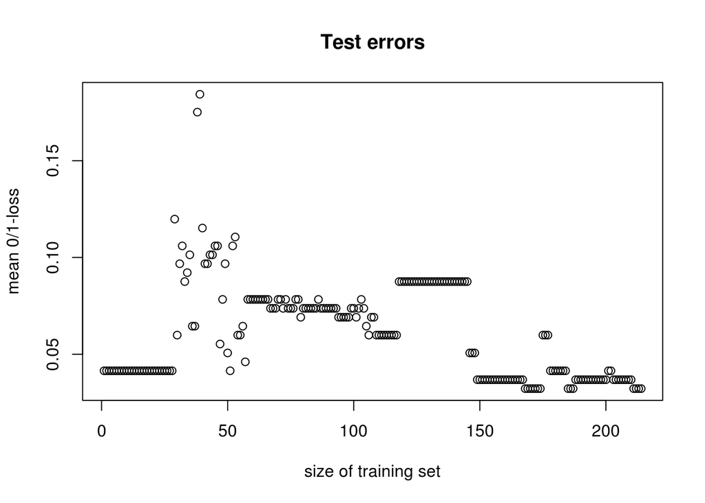

```r
tryGetLoss <- function(tempTrain) {
  lr <- glm(party ~., data = tempTrain, family = binomial("logit"))
  lr.prob = predict(lr, newdata = Test, type = "response")
  lr.pred = ifelse(lr.prob > 0.5, "republican", "democrat")
  mean(lr.pred != Test$party)
}
getLRloss <- function(Train) {
  lossLR <- rep(1, length(dim(Train)[1]))
  for(n in 1:218) {
    tempTrain <- Train[1:n, ]
    lossLR[n] <- tryCatch(tryGetLoss(tempTrain), error = function(c) 1)
  }
  return(lossLR)
}
lossLR <- getLRloss(Train)
plot(lossLR[lossLR < 1], xlab = "size of training set", ylab = "mean 0/1-loss", main = 'Test errors')
```

### 3. Logistic Regression on two attributes

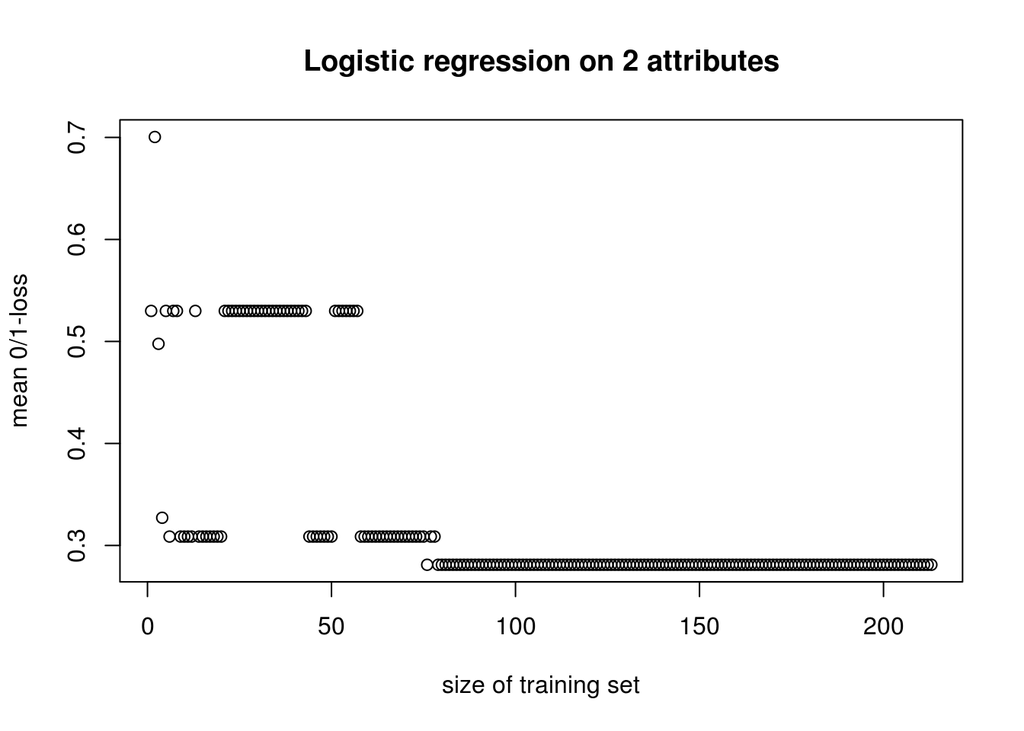

```r
getLR2loss <- function(Train) {
  lossLR2 <- numeric(dim(Train)[1])
  for(n in 1:218) {
    length(lossLR2)
    tempTrain <- Train[1:n, 1:3]
    lossLR2[n] <- tryCatch(tryGetLoss(tempTrain), error = function(c) {1},
                           warning = function(c) {1})
  }
  return(lossLR2)
}
lossLR2 <- getLR2loss(Train)
plot(lossLR2[lossLR2 < 1], xlab = "size of training set", ylab = "mean 0/1-loss", main = "Logistic regression on 2 attributes")
```

In this case, the result is nearly not as good as when regressing on all variables. It isn’t even as good as Naive Bayes. Interestingly, performance does not improve after seeing approximately $n=75$ training examples. Perhaps all useful possible combinations of the 2 features and the class have been seen at this point. The test and trianing error equal 0.281 and 0.339, respectively. It is very surprising that the training error is the highest of the two. The difference is not very big, but we are definitely not overfitting here. This is actually not very surprising, since the model is very simple. Now, 0 cases are predicted with certainty 0.9.

### 4. Comparison

We write a wrapper method `getLosses` for calculating the losses of the three algorithms (Naive Bayes, logistic regression and subset logistic regression) all at once. Then, we calculate the mean performance over multiple runs. We average the result to obtain a somewhat smoother plot. In the resulting figure, the three Naive Bayes versions are indistinguishable from eachother.

```r
calculateMeanPerformance <- function(reps = 10){
  # input: dataset of wich loss should be calculated. Either test or train.
test <- replicate(reps, getLosses(STEP = 12), simplify = FALSE)
meanPerformance <- Reduce("+", test) / length(test) #average
meanPerformance <- na.approx(meanPerformance) # interpolate
return(meanPerformance)
}
```

```r
TestPerformance <- calculateMeanPerformance()
```

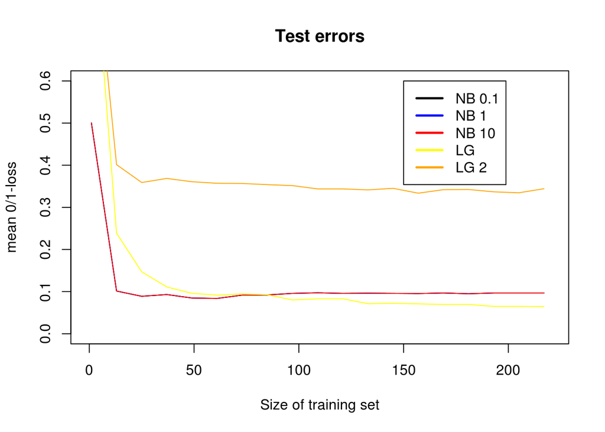

```r
plotPerformance <- function(meanPerformance) {
  plot(c(0, 220), c(0, 0.6), type = 'n',
       xlab = "Size of training set", ylab = "mean 0/1-loss",)
  colors = c("black", "blue", "red", "yellow", "orange")
  for(i in 1:5) { # 1 time NB
    lines(meanPerformance[, i], type = 'l', col = colors[i])
  }
  legend(150,0.6, c("NB 0.1", "NB 1", "NB 10",  "LG", "LG 2"), lty=rep(1, 5),
         lwd=rep(2.5, 5), col=colors)
}
plotPerformance(TestPerformance)
title(main = 'Test errors')
```

### 5. Discussion

The next question is, do the models overfit? For logistic regression, the error on the training set is lower than the test error. This indicates that this model indeed suffers from overfitting. For Naive Bayes, there is only a very small difference between the two errors and for logistic regression, the training error is actually a little bigger than the test error. This suggest that these models, especially the latter, are too simple, and would benefit from adding some complexity. In the case of logistic regression, this is obvious: we would do better when including more than just 2 features in the model. In case of Naive Bayes, this hints that the assumption of independent feature values is actually too simple.

### 6. Penalized logistic regression

We use the package `glmnet` for penalized regression. First, we plot the coefficients versus the penalization factor $\lambda$, and estimate the optimal $\lambda$. by cross validation.

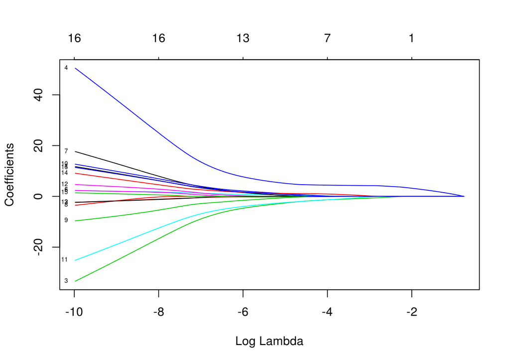

```r
# Convert feature values to numeric
x <- sapply(Train[, -1], as.numeric) # N == 2, Y == 1.
y <- Train[,1]
# Perform regression:
penalizedLR <-  glmnet(x, y, family = "binomial")
plot(penalizedLR, xvar = "lambda", label = TRUE)
```

```r
# Use cross validation to estimate best lambda
cvPenalizedLR<-cv.glmnet(x, y, family="binomial", nfolds=10)
```

Finally, we will use the optimal lambda to make a prediction.

The error on the test set equals Error rate: 0.023. This is an improvement over both Naive Bayes and non-penalized logistic regression. Plotting the test error shows that this methods performance behaves somewhat erradic, because we did not perform multiple runs as for the other methods. The real advantage of penalizing shows when looking at the performance for different sample sizes. Even for very small sample sizes, we are very close to the ‘asymptotic’ error rate! Hence, penalized logistic regression provides the best predictions, it does this also much, much faster than Naive Bayes. This indicates that the method should be preferred even for small sample sizes.

[figure not shown]

```r
plotPerformance(TestPerformance)
title(main = 'Test errors')
```